# What is the impact of the Airline, the Origin and Destination Airports, the Week day, the Month Day and the Time of the flight in delays and cancellations?

# How do different Flight times compare on different levels of Flight Arrival Delays?

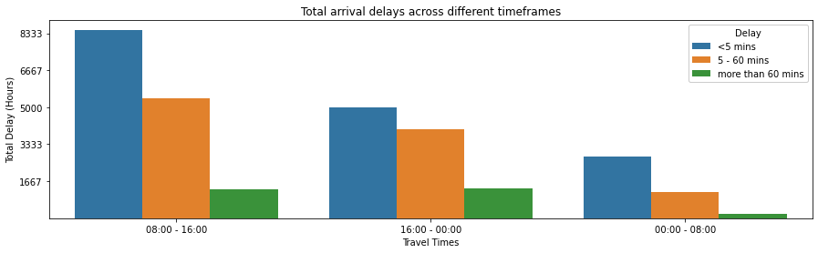

```python
plt.figure(figsize=(15,4))

position = [0,1,2]
names = ['08:00 - 16:00', '16:00 - 00:00', '00:00 - 08:00' ]
yposition = [100000, 200000, 300000, 400000, 500000]
ynames = [round(i/60) for i in yposition]

sb.countplot(data = delaysclean, x = 'TimePopularityLvl', hue = 'ArrDelayLevel')
plt.xlabel('Travel Times')
plt.ylabel('Total Delay (Hours)')
plt.xticks(position, names)
plt.yticks(yposition, ynames)
plt.title('Total arrival delays across different timeframes')
plt.legend(title='Delay', loc=1, labels=['<5 mins', '5 - 60 mins', 'more than 60 mins'],framealpha = 1);
```

## Flights that took place between 8am and 4pm, had the most Minor and Significant arrival delays. Flights that took place between 4pm and 12pm, were second in these delay levels but first in Major delays. However, the difference in Major delays is tiny small.

### Flights that took place between 12am and 8am had the least arrival delays overall.

# How do different Flight times compare on different levels of Flight Departure Delays?

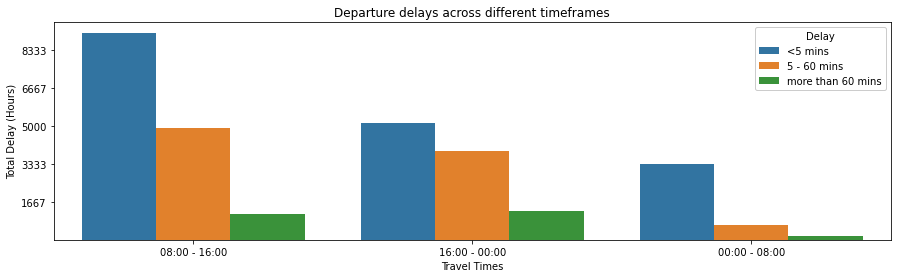

```python
plt.figure(figsize=(15,4))

position = [0,1,2]
names = ['08:00 - 16:00', '16:00 - 00:00', '00:00 - 08:00' ]
yposition = [100000, 200000, 300000, 400000, 500000]
ynames = [round(i/60) for i in yposition]

sb.countplot(data = delaysclean, x = 'TimePopularityLvl', hue = 'DepDelayLevel')
plt.xlabel('Travel Times')
plt.ylabel('Total Delay (Hours)')
plt.xticks(position, names)
plt.yticks(yposition, ynames)
plt.title('Departure delays across different timeframes')
plt.xticks(position, names)
plt.legend(title='Delay', loc=1, labels=['<5 mins', '5 - 60 mins', 'more than 60 mins'],framealpha = 1);
```

## Same picture with the Departure delays as well.

## Flights that took place between 8am and 4pm, had the most Minor and Significant delays. Flights that took place between 4pm and 12pm, were second in the same delay levels, but first in Major delays. Once again, the difference in Major delays is tiny small.

### Flights that took place between 12am and 8am had the least arrival delays overall.